# How does philosophy evolves

Jingwei Liao

This is the R notebook of the first project which will seek out some underlying stories behind the history of Philosophy. By applying data mining, statistical analysis and visualization technique in R environment, we had our preliminary exploration in **the evolution of philosophy**, including the changes in philosophers’ preferences for sentence length, main topics that philosophers discuss in different periods, the sentiment changes in the philosophy.

Most of the code in this notebook has been hidden, the whole notebook can be viewed in another notebook file.

The data of this notebook can be found on [History of Philosophy](https://www.kaggle.com/kouroshalizadeh/history-of-philosophy/version/3).

# Step 0: Initialize the Environment

```r
packages.used=c("tm", "wordcloud", "RColorBrewer",
                "tidyverse", "tidytext", "knitr",
                "DT", "htmlwidgets", "cowplots")

# check packages that need to be installed.
packages.needed=setdiff(packages.used,
                        intersect(installed.packages()[,1],
                                  packages.used))
# install additional packages
if(length(packages.needed)>0){
  install.packages(packages.needed, dependencies = TRUE,
                   repos='http://cran.us.r-project.org')
}

library(tm)
library(wordcloud)
library(RColorBrewer)
library(tidyverse)
library(tidytext)
library(knitr)
library(DT)
library(htmlwidgets)
library(cowplot)

theme_set(theme_light())
color1 <- brewer.pal(9, "YlGnBu")
color2 <- brewer.pal(9, "Blues")
```

This notebook was prepared with the following environmental settings.

```r
print(R.version)
```

```
##                _
## platform       aarch64-apple-darwin20
## arch           aarch64
## os             darwin20
## system         aarch64, darwin20
## status
## major          4
## minor          1.2
## year           2021
## month          11
## day            01
## svn rev        81115
## language       R
## version.string R version 4.1.2 (2021-11-01)
## nickname       Bird Hippie
```

# Step 1: Read in the Data

The first 6 lines of the dataset shows as follows:

```r
data <- read.csv('../data/philosophy_data.csv')
head(data)
```

|  | title | author | school | sentence_spacy | sentence_str | original_publication_date | corpus_edition_date | sentence_length | sentence_lowered | tokenized_txt | lemmatized_str |
| --- | --- | --- | --- | --- | --- | --- | --- | --- | --- | --- | --- |
| 1 | Plato - Complete Works | Plato | plato | What's new, Socrates, to make you leave your usual haunts in the Lyceum and spend your time here by the king archon's court? | What's new, Socrates, to make you leave your usual haunts in the Lyceum and spend your time here by the king archon's court? | -350 | 1997 | 125 | what's new, socrates, to make you leave your usual haunts in the lyceum and spend your time here by the king archon's court? | ['what', 'new', 'socrates', 'to', 'make', 'you', 'leave', 'your', 'usual', 'haunts', 'in', 'the', 'lyceum', 'and', 'spend', 'your', 'time', 'here', 'by', 'the', 'king', 'archon', 'court'] | what be new , Socrates , to make -PRON- leave -PRON- usual haunt in the Lyceum and spend -PRON- time here by the king archon 's court ? |
| 2 | Plato - Complete Works | Plato | plato | Surely you are not prosecuting anyone before the king archon as I am? | Surely you are not prosecuting anyone before the king archon as I am? | -350 | 1997 | 69 | surely you are not prosecuting anyone before the king archon as i am? | ['surely', 'you', 'are', 'not', 'prosecuting', 'anyone', 'before', 'the', 'king', 'archon', 'as', 'am'] | surely -PRON- be not prosecute anyone before the king archon as -PRON- be ? |
| 3 | Plato - Complete Works | Plato | plato | The Athenians do not call this a prosecution but an indictment, Euthyphro. | The Athenians do not call this a prosecution but an indictment, Euthyphro. | -350 | 1997 | 74 | the athenians do not call this a prosecution but an indictment, euthyphro. | ['the', 'athenians', 'do', 'not', 'call', 'this', 'prosecution', 'but', 'an', 'indictment', 'euthyphro'] | the Athenians do not call this a prosecution but an indictment , Euthyphro . |
| 4 | Plato - Complete Works | Plato | plato | What is this you say? | What is this you say? | -350 | 1997 | 21 | what is this you say? | ['what', 'is', 'this', 'you', 'say'] | what be this -PRON- say ? |
| 5 | Plato - Complete Works | Plato | plato | Someone must have indicted you, for you are not going to tell me that you have indicted someone else. | Someone must have indicted you, for you are not going to tell me that you have indicted someone else. | -350 | 1997 | 101 | someone must have indicted you, for you are not going to tell me that you have indicted someone else. | ['someone', 'must', 'have', 'indicted', 'you', 'for', 'you', 'are', 'not', 'going', 'to', 'tell', 'me', 'that', 'you', 'have', 'indicted', 'someone', 'else'] | someone must have indict -PRON- , for -PRON- be not go to tell -PRON- that -PRON- have indict someone else . |
| 6 | Plato - Complete Works | Plato | plato | But someone else has indicted you? | But someone else has indicted you? | -350 | 1997 | 34 | but someone else has indicted you? | ['but', 'someone', 'else', 'has', 'indicted', 'you'] | but someone else have indict -PRON- ? |

# Step 2: Explotory Data Analysis

## 1. Overview of the dataset

- **Data size**

```r
dim(data)
```

```
## [1] 360808     11
```

We can see that the dataset consists of **11 columns** and **over 36w rows**. According to the description of the dataset on Kaggle, this dataset contains over 300,000 sentences from over 50 texts spanning 10 major schools of philosophy, which means that each row represents a sentence in a text.

- **Columns**

```r
colnames(data)
```

```
##  [1] "title"                     "author"
##  [3] "school"                    "sentence_spacy"
##  [5] "sentence_str"              "original_publication_date"
##  [7] "corpus_edition_date"       "sentence_length"
##  [9] "sentence_lowered"          "tokenized_txt"
## [11] "lemmatized_str"
```

- **Feature** `school`

```r
unique(data$school)
```

```
##  [1] "plato"           "aristotle"       "empiricism"      "rationalism"
##  [5] "analytic"        "continental"     "phenomenology"   "german_idealism"
##  [9] "communism"       "capitalism"      "stoicism"        "nietzsche"
## [13] "feminism"
```

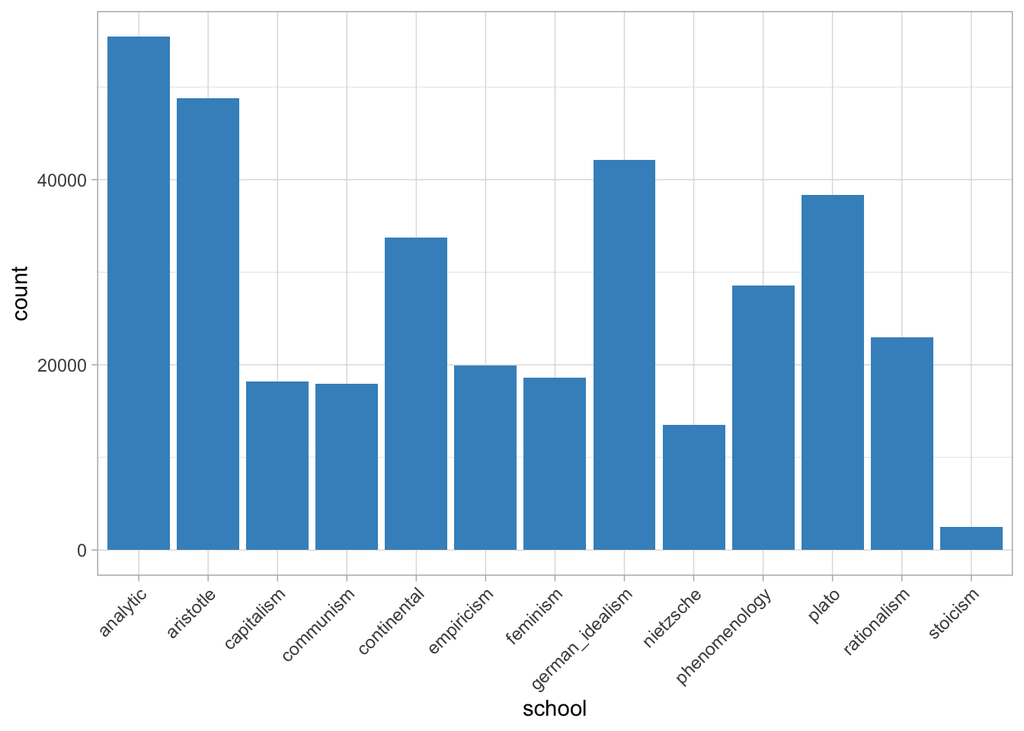

- **Feature** `author`

```r
unique(data$author)
```

```
##  [1] "Plato"           "Aristotle"       "Locke"           "Hume"
##  [5] "Berkeley"        "Spinoza"         "Leibniz"         "Descartes"
##  [9] "Malebranche"     "Russell"         "Moore"           "Wittgenstein"
## [13] "Lewis"           "Quine"           "Popper"          "Kripke"
## [17] "Foucault"        "Derrida"         "Deleuze"         "Merleau-Ponty"
## [21] "Husserl"         "Heidegger"       "Kant"            "Fichte"
## [25] "Hegel"           "Marx"            "Lenin"           "Smith"
## [29] "Ricardo"         "Keynes"          "Epictetus"       "Marcus Aurelius"
## [33] "Nietzsche"       "Wollstonecraft"  "Beauvoir"        "Davis"
```

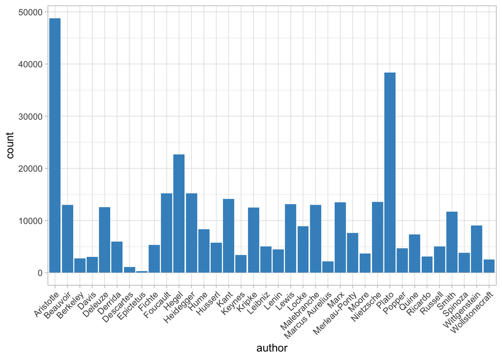

- **Feature** `Publication date range`

```
## [1] "The history of philosophy in this dataset ranges from -350 to 1985"
```

## 2. Sentence Length(by chr & word)

Sentence length can be presented as `character length` or `word length`. Since the data contains the character length in the column `sentence_length` and sentences are already tokenized, we just need to count the number of tokens in each sentence and add column `word_sentence`. Then we calculate the total sentence length and average sentence length for each text. The results are as below.

|  | school | author | title | n_chr | n_word | ave_chr | ave_word |
| --- | --- | --- | --- | --- | --- | --- | --- |
| 1 | analytic | Kripke | Naming And Necessity | 323237 | 53869 | 120.57 | 20.09 |
| 2 | analytic | Kripke | Philosophical Troubles | 1162077 | 190276 | 118.6 | 19.42 |
| 3 | analytic | Lewis | Lewis - Papers | 1439495 | 238665 | 109.72 | 18.19 |
| 4 | analytic | Moore | Philosophical Studies | 613491 | 109292 | 167.25 | 29.8 |
| 5 | analytic | Popper | The Logic Of Scientific Discovery | 652792 | 104209 | 139.55 | 22.28 |
| 6 | analytic | Quine | Quintessence | 896877 | 146368 | 121.64 | 19.85 |
| 7 | analytic | Russell | The Analysis Of Mind | 501079 | 84692 | 142.64 | 24.11 |
| 8 | analytic | Russell | The Problems Of Philosophy | 241084 | 41839 | 154.54 | 26.82 |
| 9 | analytic | Wittgenstein | On Certainty | 157485 | 28134 | 79.38 | 14.18 |
| 10 | analytic | Wittgenstein | Philosophical Investigations | 487924 | 87747 | 83.58 | 15.03 |

[output cut: 49 more lines]

To view from a more concrete point of view, the average sentence length(word) for each school is also plotted below. We can see that **capitalism** and **empiricism** use more lengthy sentences, while **analytic** and **nietzsche** use more shorter sentences.

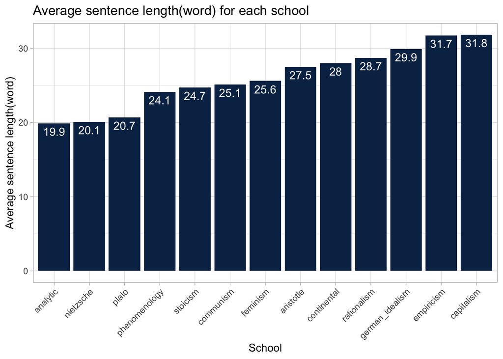

By and large, the distribution of the sentence length follows a normal distribution.

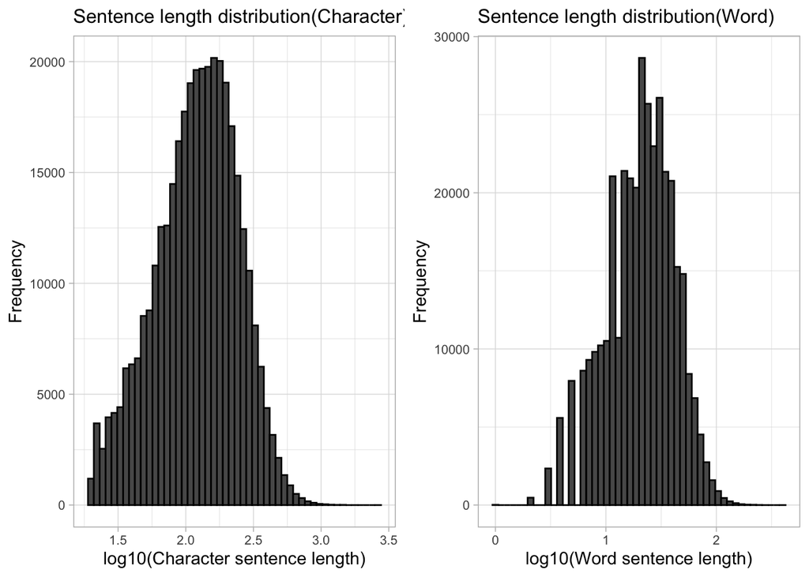

# Step 3: Data Analysis - Philosophy Evolution

Now we are interested in how Philosophy has developed over time. The scholar has divided philosophy into four periods: ancient(700 B.C -500 A.D.), medieval(6th-16th Century), modern(16th-18th Century), contemporary(19th-21st Century), thus I applied this division to our dataset, it consists of three pieces, **Ancient Philosophy**, **Modern Philosophy** and **Contemporary Philosophy**, which may indicate their characteristic change.

```r
ancient_data <- data_new %>%
  filter(original_publication_date == -350 | original_publication_date == -320)
modern_data <- data_new %>%
  filter(original_publication_date > 1600 & original_publication_date <= 1800)
contemporary_data <- data_new %>%
  filter(original_publication_date > 1800)
```

We identify the specific schools in each period and count the number of works in each school. As the plot shows, the philosophy schools are more diversified as the time went by, changing from 2 schools to 8 schools. This is in line with the normal thinking. With the transition in times and the development of science, people’s way of thinking has gradually changing from single to multiple. Naturally, there will be more schools of philosophy today and in the future. Aside, this conclusion also depends on the assumption that this dataset contains the most schools in the history of philosophy.

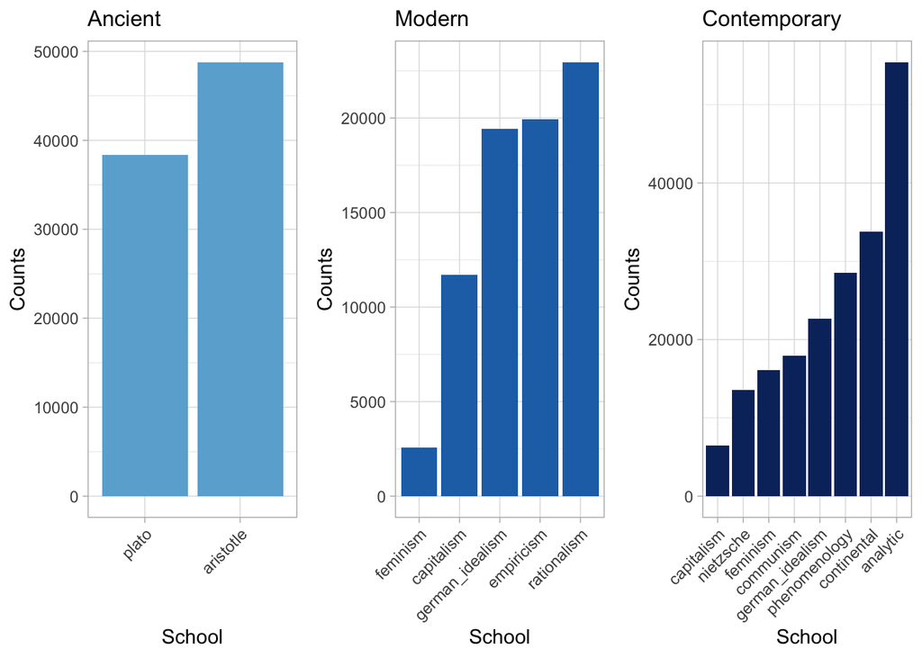

The next thing we want to explore is that can we identify the times’ characteristic by finding the characteristic of the philosophy schools in that time. Philosophy represents people’s most firmly-held beliefs, and how does this kind of beliefs evolved? That is the question we want to explore.

## 1. Changes in philosophers’ preferences for sentence length

With the sentence length analysis before, let’s first kook at how does the sentence length evolves with the time.

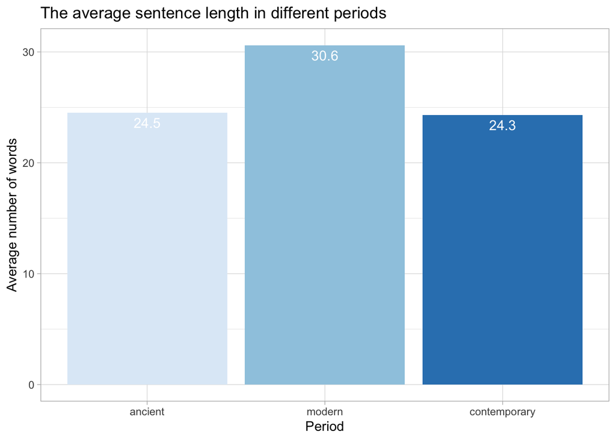

We can really find that in the modern time, the philosophers prefer longer sentences while in both ancient and contemporary times, the philosophers prefer shorter sentences. *Generally, the whole pattern changes from simplicity to complexity and finally returns to simplicity.* This phenomenon may relate to some other factors like society background, political background, cultural background and so on, and this should be discovered by professional scholars.

We can break down into more detailed category which is schools in different periods. From the plot below, we can find some interesting things. First of all, for two schools in ancient times, `plato` and `ariatotal`, their sentence length differs a lot. Secondly, `feminism` in two different times also differs a lot. For those schools that exist in different periods including `feminism`, `capitlism`, `german_idealism`, we can research more into them and that research may bring us something new indicating how the times changed.

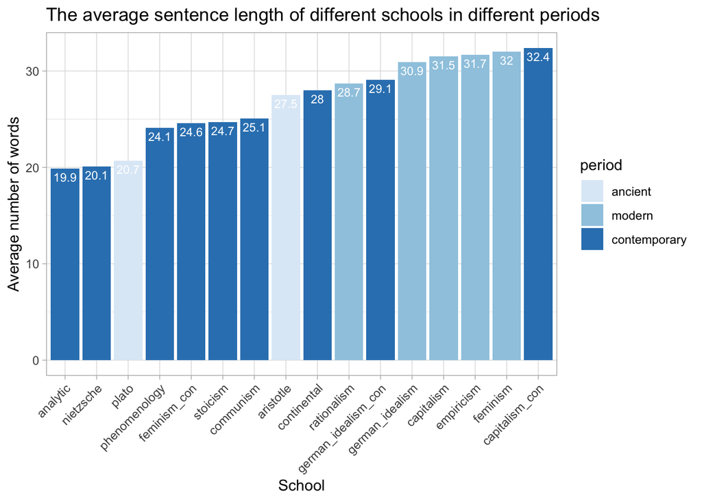

## 2. Main topics that philosophers discuss in different periods

Now we are interested in how the topics evolved with the time, we want to discover the most frequent used words in different periods. We will present via the wordcloud.

**Ancient**: `time`, `nature`, `people`, `animals`, `body`, `soul` and so on.

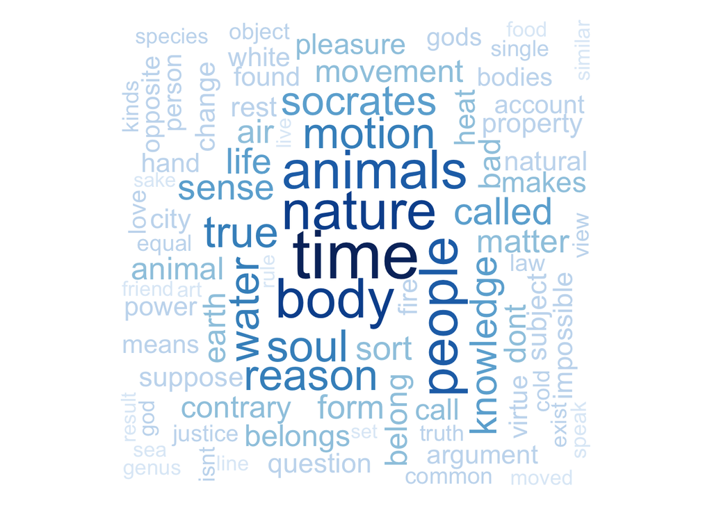

**Modern**: `reason`, `mind`, `ideas`, `nature`, `law`, `power` and so on.

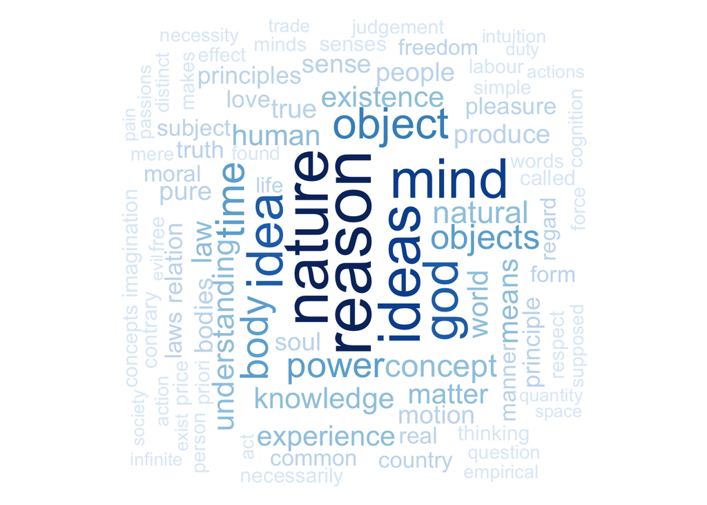

**Contemporary**: `world`, `form`, `sense`, `truth`, `consciousness`, `labour` and so on.

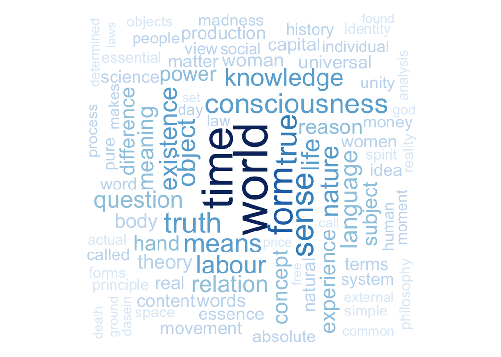

We can conclude that the topics really differ a lot in 3 periods. Ancient philosophy focuses more on **nature-related** things like water, time, animals and so on. Modern philosophy focuses more on **reasoning-related** things like mind, ideas, object, concept and so on. As for contemporary philosophy, the topics are more **realistic-related** including world, form, sense, knowledge, existence and so on.

## 3. Sentimental changes in differnt times

What are the sentiment implication of different schools in different times? Are they positive or negative? What is the reason of those sentiment patterns? Next we may explore deeply into these questions.

Using the Bing Liu lexicons, we assign each word `positive` and `negative` tag, then count the number of positive or negative words in every 80 sentences, and finally compute the sentiment score with positive number minus negative number.

Final results are shown as below. We can see some extremely negative schools like `continental` or extremely positive schools like `capitalism`, `plato` and so on.

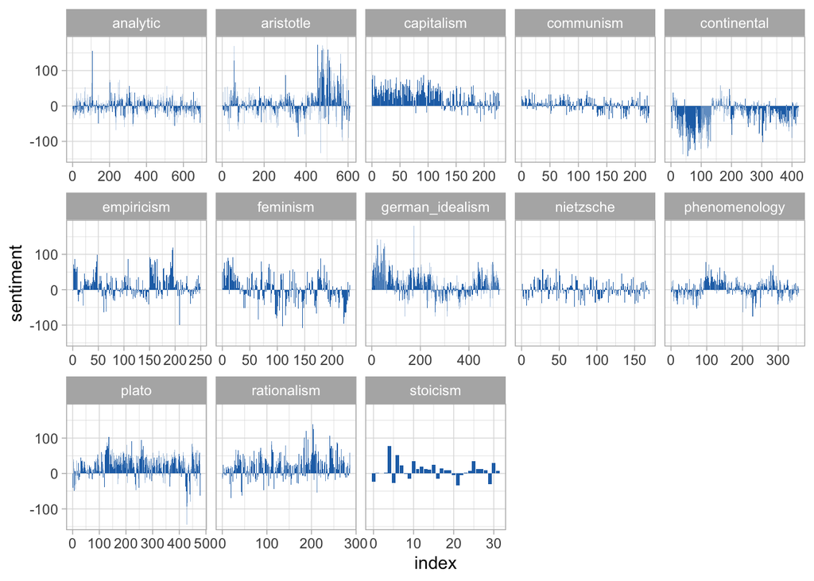

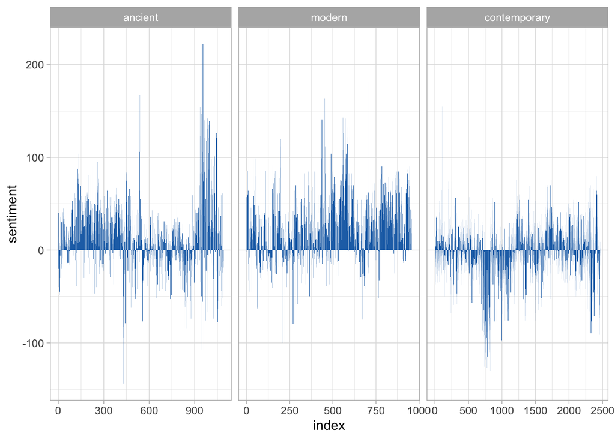

As we have discovered the macro pattern of sentiment evolution, let’s loot at the detailed sentences which lead to those positive or negative impression. Since the contemporary period is more negative than the periods before, let’s look at the top 5 negative sentences in this period.

| sentence_str | school |
| --- | --- |
| The analysis of an epidemic does not involve the recognition of the general form of the disease, by placing it in the abstract space of nosology, but the rediscovery, beneath the general signs, of the… | continental |
| But the content of pathetic madness had sixteen variants: 'amorous, jealous, avaricious, misanthropic, arrogant, irascible, abhorrent, suspicious, bashful, timid, sorrowful, distressful, nostalgic, su… | continental |
| The name under which this notion was to achieve its definitive success already signals the strange ambiguity of its structure quite clearly: on the one hand, it indicates a form of madness none of who… | continental |
| Menstrual periods are painful: headaches, stiffness, and abdominal cramps make normal activities painful and even impossible; added to these discomforts are psychic problems; nervous and irritable, th… | feminism |
| Masochistic devotion is another quite common attitude, and no less harmful for the child; some mothers make themselves slaves of their offspring to compensate for the emptiness in their hearts and to … | feminism |

Also, top 5 positive sentences in modern times.

| sentence_str | school |
| --- | --- |
| For the hope of a great good is always accompanied by great joy, and this joy is as vivid as the hope is strong because strong hope, causing the good to be imagined as present, necessarily produces jo… | rationalism |
| To love according to the rules of virtue is to love God alone and to love Him in all things; it is to love things to the extent to which they participate in the goodness and the perfections of God, si… | rationalism |
| It must be considered, then, that God loves Himself with a necessary love, and that thus He loves what in Him represents or contains greater perfection more than what contains less so much so that if … | rationalism |
| If that has never hap pened, and if it can never be expected to happen, owing to the unsuitability of the common human understanding for such subtle speculation; if rather the conviction that reaches … | german_idealism |
| Thus happiness in exact proportion with the morality of rational be ings, through which they are worthy of it, alone constitutes the highest Beurtheilung erkennt a A A A good of a world into which we … | german_idealism |

The emotions are really strong when we read these sentences. We can also find that top5 negative sentences of contemporary period are from `continental` and `feminism` and top5 positive sentences are from `rationalism`and `german_idealism`.

Except from Bing lexicon, we can also use NCR lexicon to analyze the sentiment of philosophy. The result is as below. We cannot really say that there is a huge difference between each period.

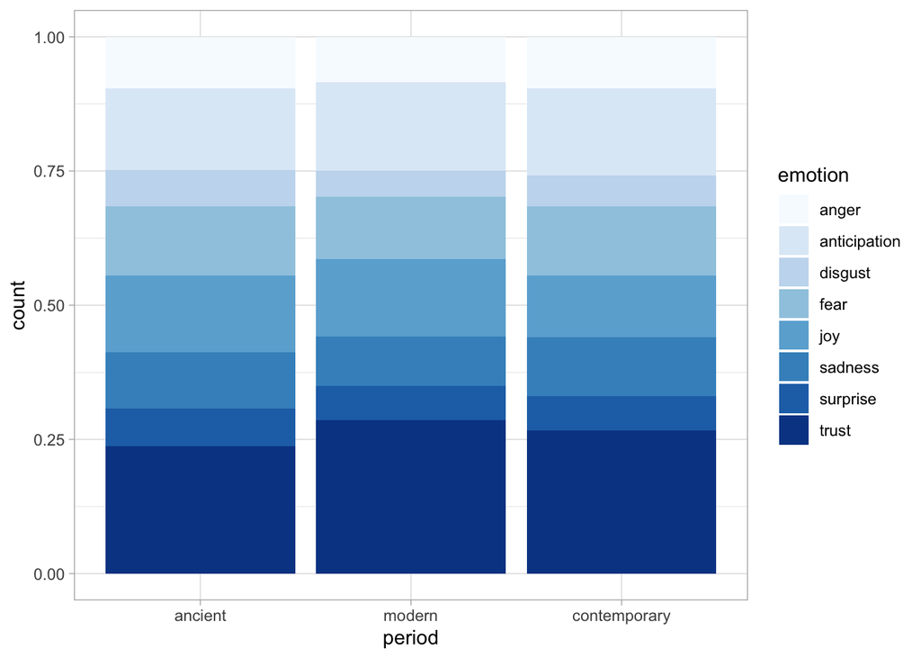

# Step 4: Conclusion

In this project, we explore the evolution of philosophy, the main conclusions are as below:

- The philosophy schools are more diversified as the time went by
- As for sentence length, generally the whole pattern changes from simplicity to complexity and finally returns to simplicity.
- Ancient philosophy focuses more on **nature-related** things, modern philosophy focuses more on **reasoning-related** things, contemporary philosophy focuses more on**realistic-related** things
- The whole sentiment of philosophy evolves from positive to negative.

More research can be done afterwards like sentiment clustering, topics modeling and so on to discover more patterns in the evolution of philosophy.